# act_report_T-2

## Wrangling Project Analysis

WeRateDogs is not as silly as it seems. Beneath the gag ratings and the punny comments, there is a rating system borne of a cold calculus—err, arithmetic. By combining it with the image prediction data and API data, we can use the ratings to find quantitative insights about breed preferences.

The ratings only *appear* haphazard. In fact, they follow a simple formula. The denominator is $10 \times n$, where $n$ is the number of dogs. There is normally one dog, and the normal denominator is 10. When there are five dogs, [the denominator is 50](https://twitter.com/dog_rates/status/709198395643068416); when there are nine dogs, [the denominator is 90](https://twitter.com/dog_rates/status/713900603437621249). Also, the numerator is on the same scale as the denominator, which means the average rating for each dog can be found by simple division.

[figure not shown]

<sup>Figure 1. Nine puppers on a bench—peep the shy one (second from the left). They are rated 99 out of 90, for an average rating of 11/10.</sup>

Once such batch ratings are accounted for, [only](https://twitter.com/dog_rates/status/670842764863651840/photo/1) [two](https://twitter.com/dog_rates/status/749981277374128128/photo/1) extraordinary ratings remain. As neither are dog ratings per se, they can be dropped. Sans outliers, the mean average rating for all the dogs is 10.9 out of 10.

To find the average ratings *per breed*, we can utilize the image prediction data. Unfortunately, most of the predictions have low confidence levels. The median confidence level is only 0.60, and that's for the best guesses! Therefore, we cannot use most of the predictions, as we need to be reasonably sure of our categorization—say, 80%. If the grouping is suspect, the validity of the group averages will be called into question. Among the tweets with usable predictions, the highest rated dogs are as follows:

| **Breed** | **No. of Tweets** | **Avg. Rating** |
| --- | --- | --- |
| Afghan Hound | 1 | 14 |
| Black and Tan Coonhound | 1 | 14 |
| Gordon Setter | 1 | 14 |
| Briard | 1 | 13 |
| Leonberger | 1 | 13 |

<sup>Table 1. The breeds are all one-of-a-kind.</sup>

Being unique appears to confer a ratings boost. This is corroborated by the distribution of ratings. Among the least common breeds—those with the fewest tweets—only the unique breeds average a rating greater than 11.

| **No. of Tweets** | **Avg. Rating** |
| --- | --- |
| 1 | 11.4 |
| 2 | 10.7 |
| 3 | 10.9 |
| 4 | 10.7 |
| 5 | 10.8 |

<sup>Table 2. These are supra-groups made up of all breeds with $n$ tweets.</sup>

The per-breed ratings correlate quite well with popular preference. There is a moderate, positive correlation (0.5982) between normalized rating and favorite count, which is a [reflection of user preference](https://medium.com/@Encore/favorites-vs-retweets-and-why-one-is-more-important-than-the-other-ba12ee20e9ba)—that is, the most-favorited dog breeds are the most preferred.

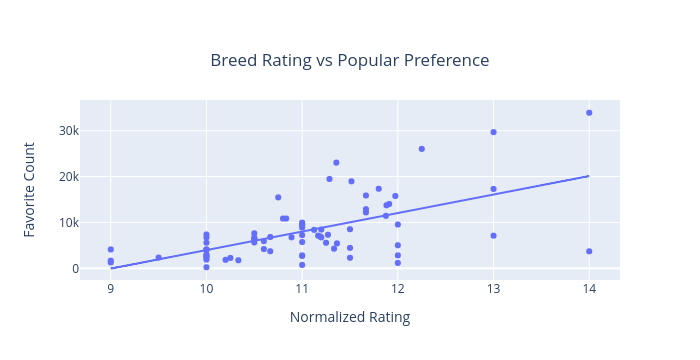

When it comes to dog breeds, WeRateDogs has its finger on the pulse of popular preference, as much as anyone can. Still, its ratings are no substitute for favorite count—itself a proxy for user preference. Of the top-five highest rated breeds, only two are among the top-five most favorited. Therefore, whenever possible, we should gauge popular preference using favorite count directly. Any conclusions based off of ratings should be viewed with skepticism and considered tentative at best.